# PARKINSON DATASET

### DENSITY PLOT

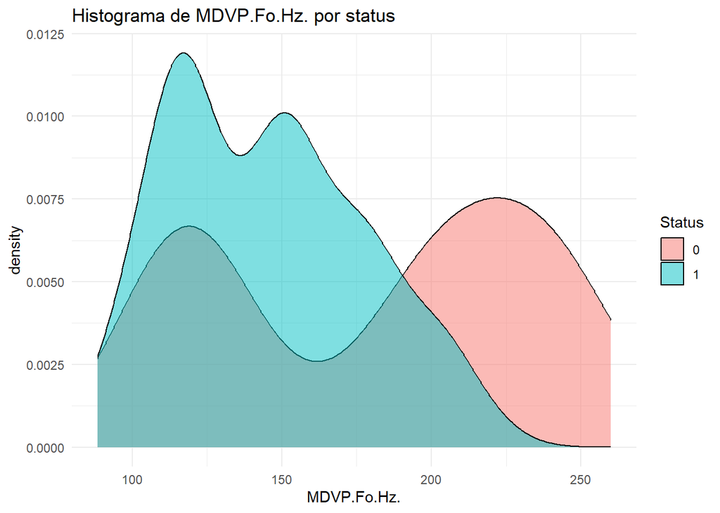

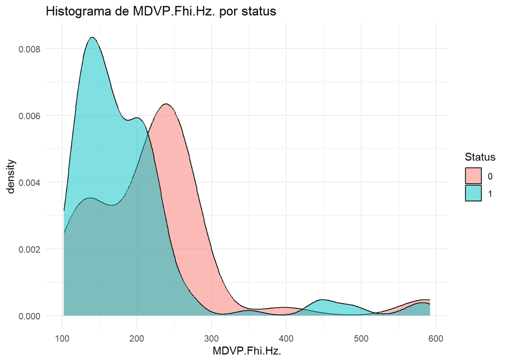

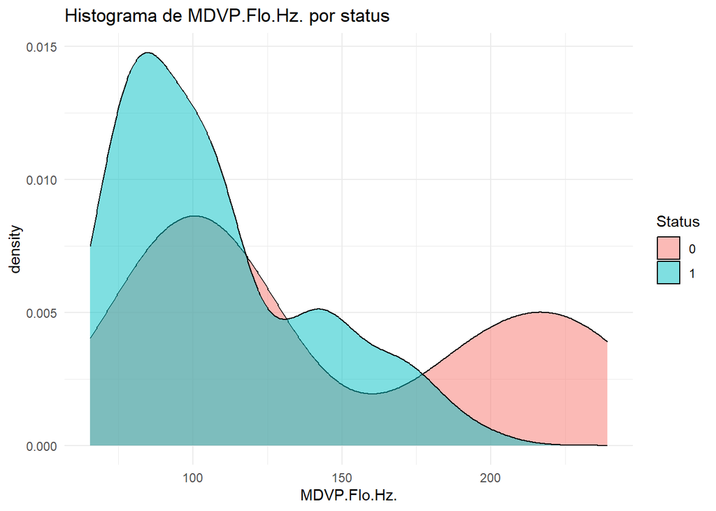

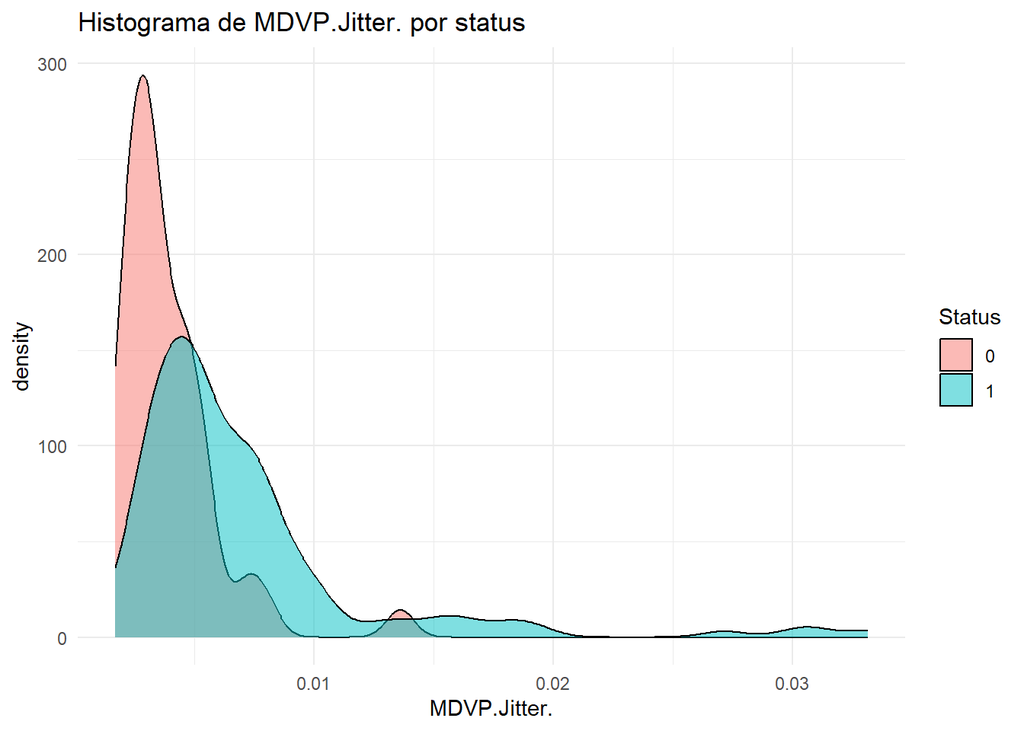

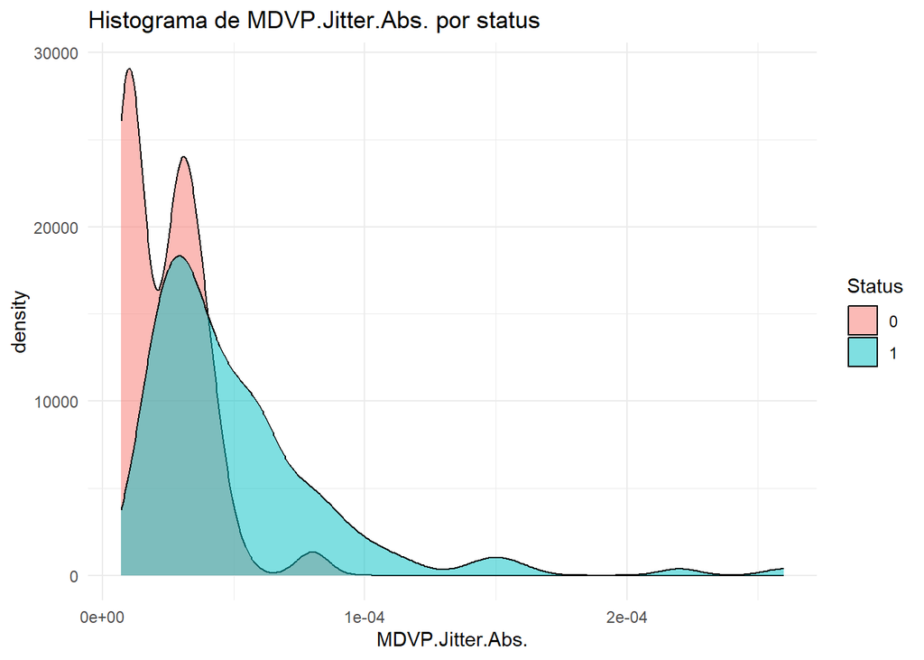

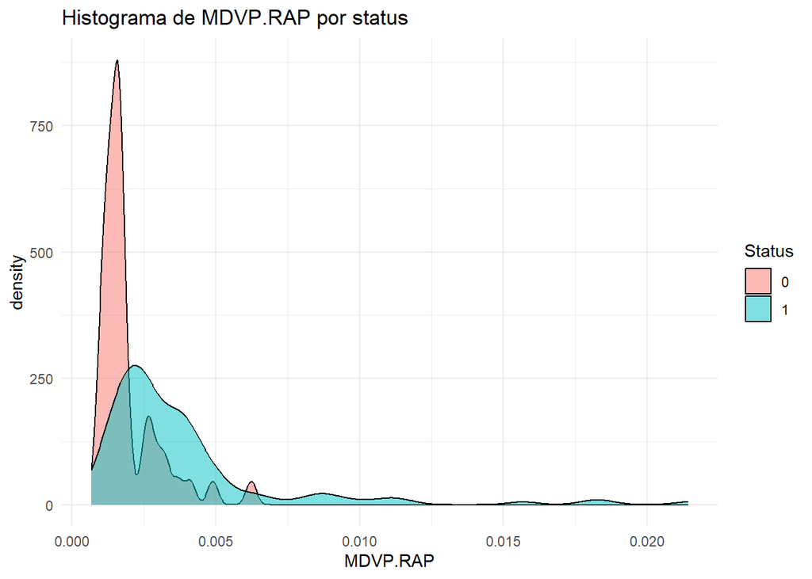

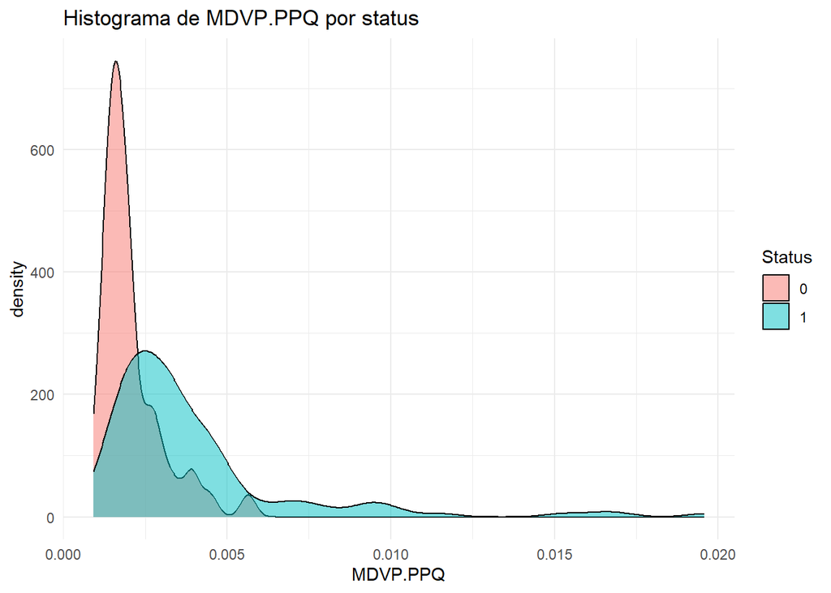

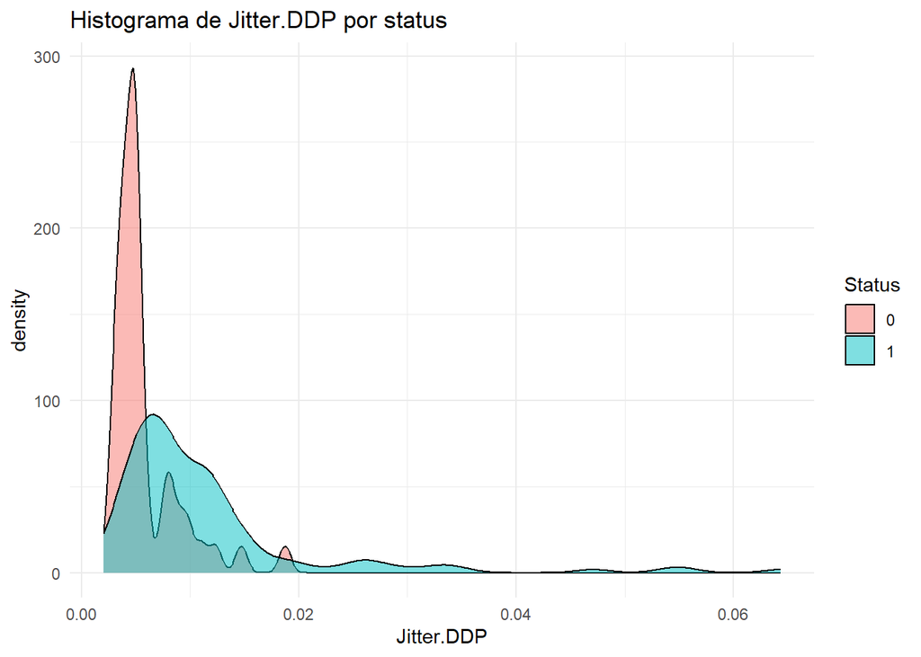

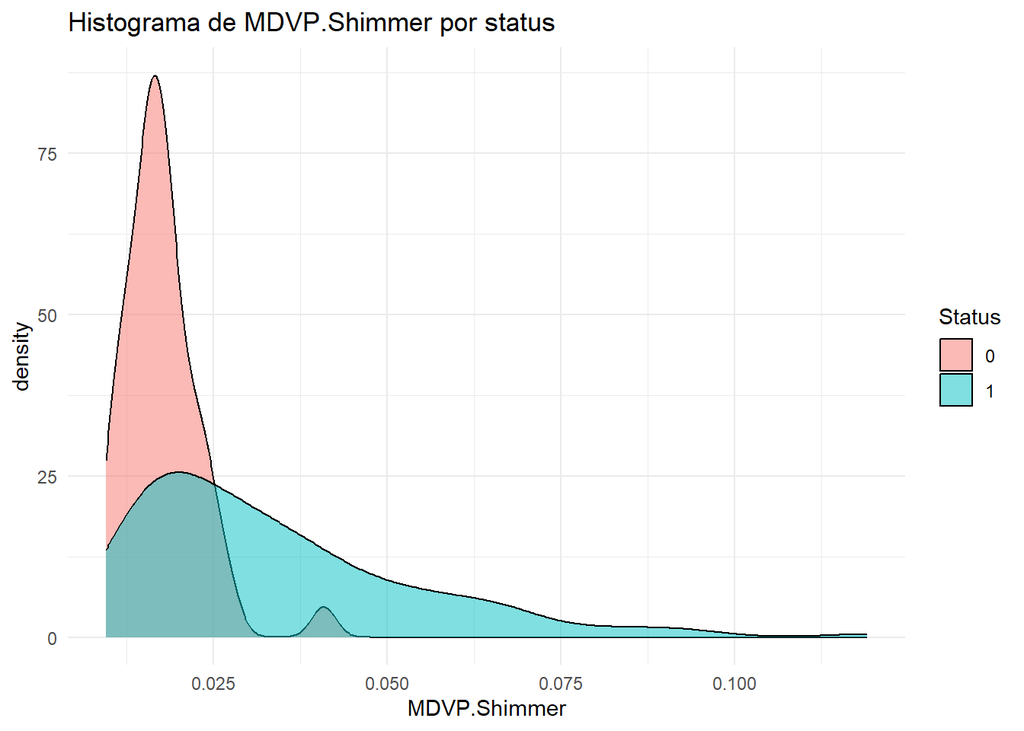

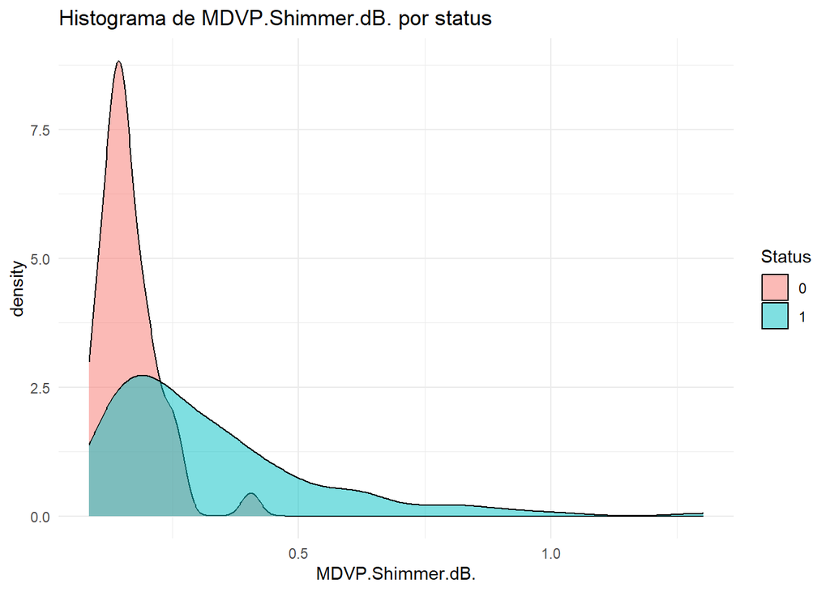

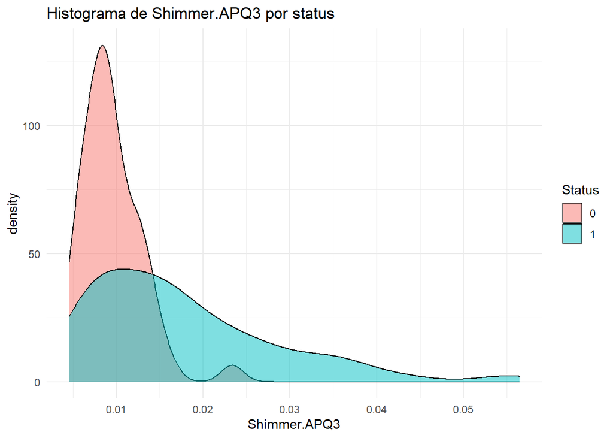

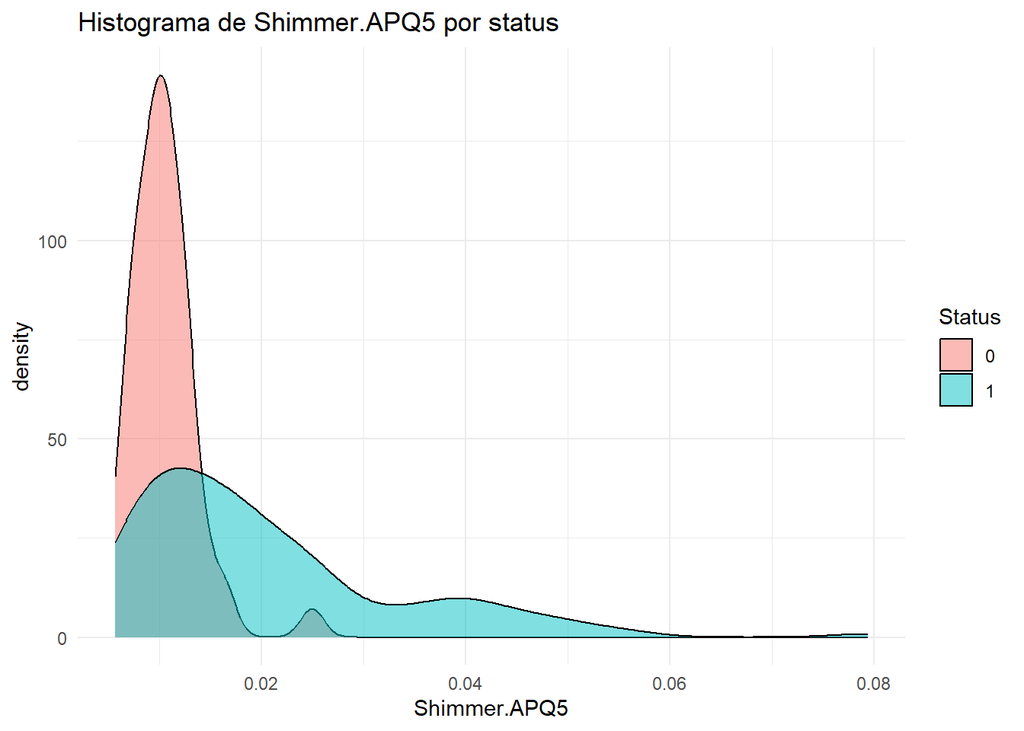

[10 more figures not shown]

```r
# Cogemos las variables numericas
variables_numericas = data %>%
  select(where(is.numeric))

# Hacemos un density plot sencillo
for (var in colnames(variables_numericas)) {
  g = ggplot(data, aes(x = variables_numericas[[var]], fill = status)) +
    geom_density(alpha = 0.5) + # Se puede añádir el facet_wrap para ver las densidades por separado
    theme_minimal() +
    labs(x = var, fill = "Status") +
    ggtitle(paste("Histograma de", var, "por status"))

  print(g)

}
```

OTRA FORMA DE VISUALIZAR NUESTROS DATOS ES A TRAVÉS DE DENSITY PLOTS, QUE ES UNA REPRESENTACION GRÁFICA DE LA DISTRIBUCION DE UNA VARIABLE CONINUA.

## RELACION VARIABLES Y SELECCIÓN DE LAS MISMAS

ES MUY IMPORTANTE VER COMO SE RELACIONAN NUESTRAS VARIABLES. EN ESTE CASO, SOLO TENEMOS VARIABLES NUMERICAS (Y LA TARGET QUE ES CATEGORICA), POR LO QUE APLICAREMOS LA CORRELACIÓN DE PEARSON.

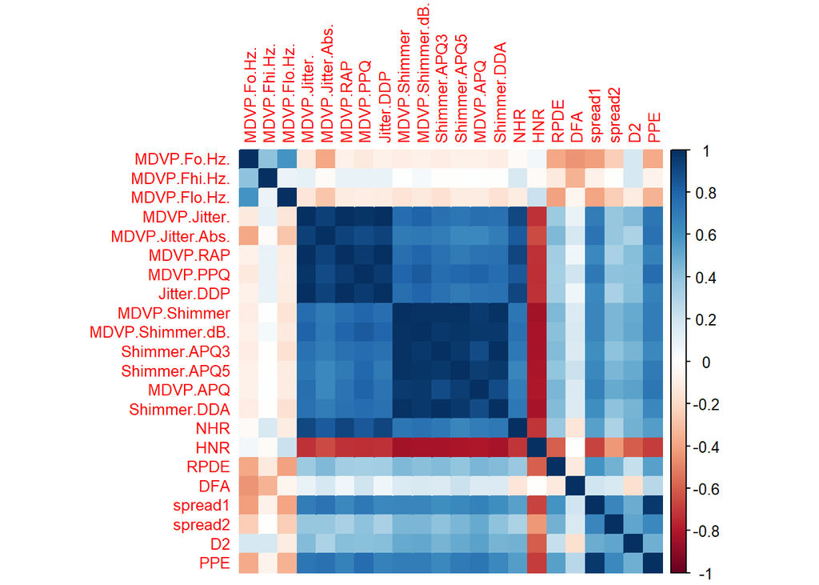

```r
# Hacemos la correlación de pearson
correlacion_numericas = cor(variables_numericas,
                            method = "pearson",
                            use = "complete.obs") # ignora valores faltantes

# La visualizamos mediante corrplot
corrplot(correlacion_numericas, method = "color", tl.cex = 0.8)
```

PODEMOS VER QUE VARIA VARIABLES ESTÁN ALTAMENTE CORRELACIONADAS, ES POR ELLO QUE PODEMOS INTENTAR QUITARNOS ALGUNAS DE ELLAS PARA QUE EL MODELO NO CONTENGA RUIDO POR PARTE DE VARIABLES CORRELACIONADAS.

```r
# Paso 2: Encontrar índices de variables altamente correlacionadas
highly_correlated_indices <- findCorrelation(correlacion_numericas, cutoff = 0.9)

# Paso 3: Crear un nuevo conjunto de datos sin las variables altamente correlacionadas
variables_no_correlacionadas <- variables_numericas[, -highly_correlated_indices]

# Verifica el nuevo conjunto de datos
head(variables_no_correlacionadas, 5)
```

```
  MDVP.Fo.Hz. MDVP.Fhi.Hz. MDVP.Flo.Hz. Shimmer.APQ5     NHR    HNR     RPDE
1     119.992      157.302       74.997      0.03130 0.02211 21.033 0.414783
2     122.400      148.650      113.819      0.04518 0.01929 19.085 0.458359
3     116.682      131.111      111.555      0.03858 0.01309 20.651 0.429895
4     116.676      137.871      111.366      0.04005 0.01353 20.644 0.434969
5     116.014      141.781      110.655      0.04825 0.01767 19.649 0.417356
       DFA   spread1  spread2       D2
1 0.815285 -4.813031 0.266482 2.301442
2 0.819521 -4.075192 0.335590 2.486855
3 0.825288 -4.443179 0.311173 2.342259
4 0.819235 -4.117501 0.334147 2.405554
5 0.823484 -3.747787 0.234513 2.332180
```

## EVALUACIÓN MODELOS

ANTES DE CONSTRUIR Y EVALUAR NUESTRO MODELO, DEBEMOS ESCALAR NUESTRAS VARIABLES.

```r
# Scale dataset

# Paso 1: Calcular parámetros de preprocesamiento
normParams <- preProcess(variables_no_correlacionadas, method=c("range"))

# Paso 2: Imprimir los parámetros de preprocesamiento
print(normParams)
```

```
Created from 195 samples and 11 variables

Pre-processing:
  - ignored (0)
  - re-scaling to [0, 1] (11)
```

```r
# Paso 3: Transformar el nuevo conjunto de datos
variables_no_correlacionadas <- predict(normParams, variables_no_correlacionadas)

# Paso 4: Agregar la variable objetivo
nuevo_dataset <- cbind(variables_no_correlacionadas, status = data$status)

# Paso 5: Resumen del nuevo conjunto de datos
summary(nuevo_dataset)
```

```
  MDVP.Fo.Hz.      MDVP.Fhi.Hz.      MDVP.Flo.Hz.     Shimmer.APQ5
 Min.   :0.0000   Min.   :0.00000   Min.   :0.0000   Min.   :0.00000
 1st Qu.:0.1702   1st Qu.:0.06679   1st Qu.:0.1083   1st Qu.:0.05265
 Median :0.3520   Median :0.15041   Median :0.2236   Median :0.10543
 Mean   :0.3836   Mean   :0.19384   Mean   :0.2927   Mean   :0.16524
 3rd Qu.:0.5498   3rd Qu.:0.24916   3rd Qu.:0.4292   3rd Qu.:0.22632
 Max.   :1.0000   Max.   :1.00000   Max.   :1.0000   Max.   :1.00000
      NHR               HNR              RPDE             DFA
 Min.   :0.00000   Min.   :0.0000   Min.   :0.0000   Min.   :0.0000
 1st Qu.:0.01679   1st Qu.:0.4372   1st Qu.:0.3844   1st Qu.:0.4003
 Median :0.03504   Median :0.5545   Median :0.5586   Median :0.5895
 Mean   :0.07702   Mean   :0.5464   Mean   :0.5646   Mean   :0.5730
 3rd Qu.:0.07954   3rd Qu.:0.6760   3rd Qu.:0.7723   3rd Qu.:0.7474
 Max.   :1.00000   Max.   :1.0000   Max.   :1.0000   Max.   :1.0000
    spread1          spread2             D2         status
 Min.   :0.0000   Min.   :0.0000   Min.   :0.0000   0: 48
 1st Qu.:0.2739   1st Qu.:0.3784   1st Qu.:0.3007   1:147
 Median :0.4057   Median :0.4786   Median :0.4174
 Mean   :0.4123   Mean   :0.4958   Mean   :0.4264
 3rd Qu.:0.5277   3rd Qu.:0.6145   3rd Qu.:0.5397
 Max.   :1.0000   Max.   :1.0000   Max.   :1.0000
```

PODEMOS OBSERVAR LAS VARIABLES NUMERICAS QUE NO ESTÁN ALTAMENTE CORRELACIONADAS, ESCALADAS. EL ESCALAMIENTO ES IMPORTANTE SIEMPRE, AUNQUE SE VUELVE FUNDAMENTAL CUANDO NUESTROS DATOS ESTÁN EN DISTINTAS MEDIDAS (EJEMPLO: KG Y LITROS)

```r
str(nuevo_dataset)
```

```
'data.frame':   195 obs. of  12 variables:
 $ MDVP.Fo.Hz. : num  0.184 0.198 0.165 0.165 0.161 ...
 $ MDVP.Fhi.Hz.: num  0.1126 0.0949 0.0591 0.0729 0.0809 ...
 $ MDVP.Flo.Hz.: num  0.0548 0.2783 0.2653 0.2642 0.2601 ...
 $ Shimmer.APQ5: num  0.347 0.536 0.446 0.466 0.577 ...
 $ NHR         : num  0.0683 0.0593 0.0396 0.041 0.0542 ...
 $ HNR         : num  0.512 0.433 0.496 0.496 0.455 ...
 $ RPDE        : num  0.369 0.471 0.404 0.416 0.375 ...
 $ DFA         : num  0.96 0.977 1 0.976 0.993 ...
 $ spread1     : num  0.57 0.703 0.637 0.696 0.762 ...
 $ spread2     : num  0.586 0.741 0.686 0.738 0.514 ...
 $ D2          : num  0.391 0.473 0.409 0.437 0.404 ...
 $ status      : Factor w/ 2 levels "0","1": 2 2 2 2 2 2 2 2 2 2 ...
```

AQUI VUELVO A VER LA ESTRUCTURA DE MI DATASET FINAL PARA PODER OBSERVARLO BIEN Y VER QUE TODO ESTÁ LISTO.

### PARTICIÓN DE DATOS, CONSTRUCCIÓN DEL MODELO Y EVALUACIÓN POR VALIDACION CRUZADA

ANTES DE EMPEZAR A CONSTRUIR EL MODELO, ES IMPORTANTE PARTIR LOS DATOS Y HACER UN TRAINCONTROL PARA LA EVALUACIÓN DEL MISMO. SE UTILIZARÁ COMO MÉTODO DE EVALUACIÓN, EL CROSS VALIDATIÓN, CON 10 K-FOLDS Y 3 REPETICIONES, PARA MAYOR EXACTITUD. ADEMÁS, UTILIZAREMOS UNA MÉTRICA SENCILLA PERO POTENTE PARA VER QUE MODELO SE COMPORTA MEJOR, LA PRECISIÓN (ACCURACY)

```r
# Cargar librerías
library(caret)
library(randomForest)
library(e1071)

# Establecer semilla para reproducibilidad
set.seed(123)

# Preparar datos
train_index <- createDataPartition(nuevo_dataset$status, p = 0.8, list = FALSE)
train_data <- nuevo_dataset[train_index, ]
test_data <- nuevo_dataset[-train_index, ]

# Configurar el método de validación cruzada
train_control <- trainControl(method = "repeatedcv", number = 10, repeats = 3)

# Ajustar el modelo de regresión logística con validación cruzada
modelo_logistico <- train(status ~ ., data = train_data, method = "glm",
                          family = "binomial", trControl = train_control)

# Ajustar el modelo SVM con validación cruzada
modelo_svm <- train(status ~ ., data = train_data, method = "svmRadial",
                    trControl = train_control)

# Ajustar el modelo Random Forest con validación cruzada
modelo_rf <- train(status ~ ., data = train_data, method = "rf",
                   trControl = train_control)

# Imprimir resultados de los modelos
print(modelo_logistico)
```

```
Generalized Linear Model

157 samples
 11 predictor
  2 classes: '0', '1'

No pre-processing
Resampling: Cross-Validated (10 fold, repeated 3 times)
Summary of sample sizes: 142, 141, 141, 142, 141, 141, ...
Resampling results:

  Accuracy   Kappa
  0.8216667  0.49983
```

```r
print(modelo_svm)
```

```
Support Vector Machines with Radial Basis Function Kernel

157 samples
 11 predictor
  2 classes: '0', '1'

No pre-processing
Resampling: Cross-Validated (10 fold, repeated 3 times)
Summary of sample sizes: 141, 141, 142, 142, 141, 141, ...
Resampling results across tuning parameters:

  C     Accuracy   Kappa
  0.25  0.8302183  0.3912224
  0.50  0.8473214  0.4669354
  1.00  0.8603770  0.5439540

Tuning parameter 'sigma' was held constant at a value of 0.08069703
Accuracy was used to select the optimal model using the largest value.
The final values used for the model were sigma = 0.08069703 and C = 1.
```

```r
print(modelo_rf)
```

```
Random Forest

157 samples
 11 predictor
  2 classes: '0', '1'

No pre-processing
Resampling: Cross-Validated (10 fold, repeated 3 times)
Summary of sample sizes: 141, 143, 141, 141, 141, 142, ...
Resampling results across tuning parameters:

  mtry  Accuracy   Kappa
   2    0.9152381  0.7423043
   6    0.9048214  0.7208794
  11    0.8941270  0.6939410

Accuracy was used to select the optimal model using the largest value.
The final value used for the model was mtry = 2.
```

```r
# Extraer resultados de los modelos
results_logistico <- modelo_logistico$resample
results_svm <- modelo_svm$resample
results_rf <- modelo_rf$resample

# Combinar los resultados
combined_results <- rbind(
  data.frame(Modelo = "Logístico", results_logistico),
  data.frame(Modelo = "SVM", results_svm),
  data.frame(Modelo = "Random Forest", results_rf)
)

# Resumen de la precisión promedio por modelo
summary_table <- aggregate(Accuracy ~ Modelo, data = combined_results, FUN = mean)

# Crear una tabla estilizada
summary_table %>%
  kable("html", escape = FALSE, align = "c", caption = "Precisión Promedio por Modelo") %>%
  kable_styling("striped", full_width = F) %>%
  column_spec(1, bold = TRUE, color = "darkblue") %>%  # Cambiar columna 1 (Modelo)
  column_spec(2, background = "#f2f2f2") %>%           # Cambiar columna 2 (Precisión)
  row_spec(0, bold = TRUE, font_size = 14, color = "white", background = "darkblue")
```

Precisión Promedio por Modelo

| Modelo | Accuracy |
| --- | --- |
| Logístico | 0.8216667 |
| Random Forest | 0.9152381 |
| SVM | 0.8603770 |

### EXPLICACIONES Y CONCLUSIONES

**MODELO LOGISTICO**

**Muestra:** El modelo se entrenó con 157 muestras y 11 variables predictivas.

**Clases:** Hay 2 clases en la variable objetivo: ‘0’ y ‘1’.

**Accuracy:** La precisión del modelo es aproximadamente 82.17%, lo que indica que el modelo es bastante efectivo al clasificar los casos.

**Kappa:** El valor de Kappa es 0.49983, lo que sugiere que la precisión del modelo es mejor que la aleatoria, pero hay espacio para mejoras, ya que valores de Kappa cercanos a 1 indican una buena concordancia.

**SUPPORT VECTOR MACHINE**

**Muestra y Clases:** Al igual que el modelo de regresión logística, utiliza 157 muestras y 11 variables predictivas.

**Resampling:** Los tamaños de muestra son consistentes en todas las iteraciones de validación cruzada.

**Kappa:** Con un C de 1.00, Kappa es 0.5439540, lo que indica una mejora en la concordancia respecto al modelo de regresión logística.

**MODELO RANDOM FOREST**

**Muestra y Clases:** Similar a los modelos anteriores, el modelo Random Forest se entrenó con 157 muestras y 11 variables.

**Resampling:** Los tamaños de muestra varían ligeramente, pero son consistentes.

**Parámetros de Tuning:** Se reporta la precisión y Kappa para diferentes valores del parámetro mtry (número de variables aleatorias a considerar en cada división). Con mtry = 2, el modelo alcanza una precisión del 91.52% y un Kappa de 0.7423043, indicando un rendimiento notablemente mejor que los modelos anteriores.

**Conclusiones:** A medida que mtry aumenta, la precisión disminuye, lo que puede indicar que el modelo está funcionando mejor con menos variables consideradas en cada división.

**RESUMEN GENERAL**

**Mejor Modelo:** El Random Forest es el mejor modelo en términos de precisión (91.52%) y Kappa (0.7423), lo que indica una buena capacidad de clasificación.

**Desempeño del SVM:** Aunque el SVM muestra buenas métricas de precisión, el rendimiento no supera al del Random Forest.

**Desempeño de la Regresión Logística:** La regresión logística tiene la menor precisión (82.17%) y Kappa (0.49983), lo que sugiere que, si bien es un buen modelo inicial, no es el más efectivo en este caso.